# BD-11_Плевокас

```python
import pandas as pd
import datetime
import numpy as np
import matplotlib.pyplot as plt
import statsmodels.api as sm
from pylab import rcParams
import warnings
from pandas.core.nanops import nanmean as pd_nanmean
import seaborn as sns
import scipy
from IPython.display import *
from scipy import stats
from sklearn.metrics import mean_absolute_error
import plotly.express as px
from fbprophet import Prophet

warnings.filterwarnings('ignore')
rcParams['figure.figsize'] = 14, 10
%matplotlib inline
```

Авокадо - любимый фрукт моей девушки. Однако стипендия студента (или же её отсутствие) не позволяет покупать данный фрукт в достаточном объеме, чтобы удовлетворить аппетит. На кеггле был найден хороший датасет с информацией об продажах авокадо в зависимости от региона, его категории, способа выращивания. Почему бы нам не проанализировать наш датасет, чтобы понять, в какой город лучше ехать (представим, что мы живем в США), чтобы закупиться авокадо на длительное время, какие авокадо лучше брать и какие цены ожидать? Датасет взят с kaggle - https://www.kaggle.com/neuromusic/avocado-prices.

```python
df = pd.read_csv('./avocado.csv', sep =',', parse_dates=['Date'], index_col='Date')
```

```python
df = df.sort_values(by='Date') #Отсортируем по датам
```

```python
df.info()
```

```
<class 'pandas.core.frame.DataFrame'>
DatetimeIndex: 18249 entries, 2015-01-04 to 2018-03-25
Data columns (total 13 columns):
 #   Column        Non-Null Count  Dtype
---  ------        --------------  -----
 0   Unnamed: 0    18249 non-null  int64
 1   AveragePrice  18249 non-null  float64
 2   Total Volume  18249 non-null  float64
 3   4046          18249 non-null  float64
 4   4225          18249 non-null  float64
 5   4770          18249 non-null  float64
 6   Total Bags    18249 non-null  float64
 7   Small Bags    18249 non-null  float64
 8   Large Bags    18249 non-null  float64
 9   XLarge Bags   18249 non-null  float64
 10  type          18249 non-null  object
 11  year          18249 non-null  int64
 12  region        18249 non-null  object
dtypes: float64(9), int64(2), object(2)
memory usage: 1.9+ MB
```

### Получается, что у нас есть данные по средней цене, по общему количеству продаж, кол-ву продаж по типу, по количеству мешков с авокадо, их типом, а также по региону и году.

```python
df
```

| Date | Unnamed: 0 | AveragePrice | Total Volume | 4046 | 4225 | 4770 | Total Bags | Small Bags | Large Bags | XLarge Bags | type | year | region |
| --- | --- | --- | --- | --- | --- | --- | --- | --- | --- | --- | --- | --- | --- |
| 2015-01-04 | 51 | 1.75 | 27365.89 | 9307.34 | 3844.81 | 615.28 | 13598.46 | 13061.10 | 537.36 | 0.00 | organic | 2015 | Southeast |
| 2015-01-04 | 51 | 1.49 | 17723.17 | 1189.35 | 15628.27 | 0.00 | 905.55 | 905.55 | 0.00 | 0.00 | organic | 2015 | Chicago |
| 2015-01-04 | 51 | 1.68 | 2896.72 | 161.68 | 206.96 | 0.00 | 2528.08 | 2528.08 | 0.00 | 0.00 | organic | 2015 | HarrisburgScranton |
| 2015-01-04 | 51 | 1.52 | 54956.80 | 3013.04 | 35456.88 | 1561.70 | 14925.18 | 11264.80 | 3660.38 | 0.00 | conventional | 2015 | Pittsburgh |
| 2015-01-04 | 51 | 1.64 | 1505.12 | 1.27 | 1129.50 | 0.00 | 374.35 | 186.67 | 187.68 | 0.00 | organic | 2015 | Boise |
| ... | ... | ... | ... | ... | ... | ... | ... | ... | ... | ... | ... | ... | ... |
| 2018-03-25 | 0 | 1.36 | 908202.13 | 142681.06 | 463136.28 | 174975.75 | 127409.04 | 103579.41 | 22467.04 | 1362.59 | conventional | 2018 | Chicago |
| 2018-03-25 | 0 | 0.70 | 9010588.32 | 3999735.71 | 966589.50 | 30130.82 | 4014132.29 | 3398569.92 | 546409.74 | 69152.63 | conventional | 2018 | SouthCentral |
| 2018-03-25 | 0 | 1.42 | 163496.70 | 29253.30 | 5080.04 | 0.00 | 129163.36 | 109052.26 | 20111.10 | 0.00 | organic | 2018 | SouthCentral |
| 2018-03-25 | 0 | 1.70 | 190257.38 | 29644.09 | 70982.10 | 0.00 | 89631.19 | 89424.11 | 207.08 | 0.00 | organic | 2018 | California |
| 2018-03-25 | 0 | 1.34 | 1774776.77 | 63905.98 | 908653.71 | 843.45 | 801373.63 | 774634.09 | 23833.93 | 2905.61 | conventional | 2018 | NewYork |

18249 rows × 13 columns

```python
df.groupby(['region'])['AveragePrice'].mean().sort_values()[-5:]
```

```
region
Sacramento             1.621568
Philadelphia           1.632130
NewYork                1.727574
SanFrancisco           1.804201
HartfordSpringfield    1.818639
Name: AveragePrice, dtype: float64
```

### Нашли регионы с самой большой средней ценой на авокадо в среднем за 4 года: Сакраменто, Филадельфия, Нью-Йорк, Сан-Франциско и Хартфорд-Спрингфилд.

```python
df.groupby(['region'])['Total Volume'].mean().sort_values()[-15:]
```

```
region
WestTexNewMexico    4.314085e+05
PhoenixTucson       5.788264e+05
Houston             6.010884e+05
DallasFtWorth       6.166251e+05
NewYork             7.122311e+05
Plains              9.206761e+05
LosAngeles          1.502653e+06
Midsouth            1.503992e+06
GreatLakes          1.744505e+06
Southeast           1.820232e+06
Northeast           2.110299e+06
SouthCentral        2.991952e+06
California          3.044324e+06
West                3.215323e+06
TotalUS             1.735130e+07
Name: Total Volume, dtype: float64
```

### Очевидно, самое большое количество продаж наблюдается на целые округа, но среди мелких областей выделяются Калифорния, Лос-Анджелес и Нью-Йорк.

# Визуальный анализ

### Сразу же взглянем на динамику цен.

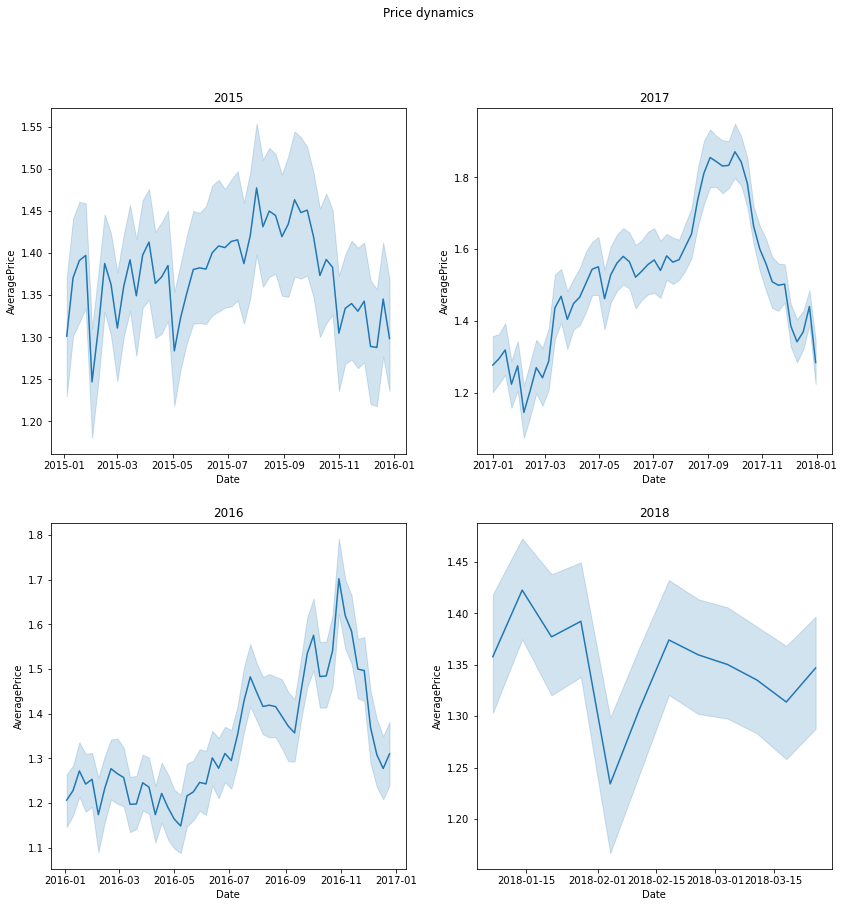

```python
f, axes = plt.subplots(2, 2, figsize=(14, 14))
f.suptitle('Price dynamics')
for i in range(4):
    first = int(i % 2)
    second = int(i / 2)
    sns.lineplot(data=df[df['year'] == 2015 + i], x='Date', y='AveragePrice',palette='magma', ax=axes[first, second])
    axes[first,second].set_title(str(2015+i))
```

### Видно, что цены вырастают к осенне-зимнему периоду. Прочитав в новостях, можно понять, что "сезон авокадо стартует в феврале и длится до сентября", что можно наблюдать на наших графиках.

### Теперь посмотрим на динамику по популярности авокадо разной категории.

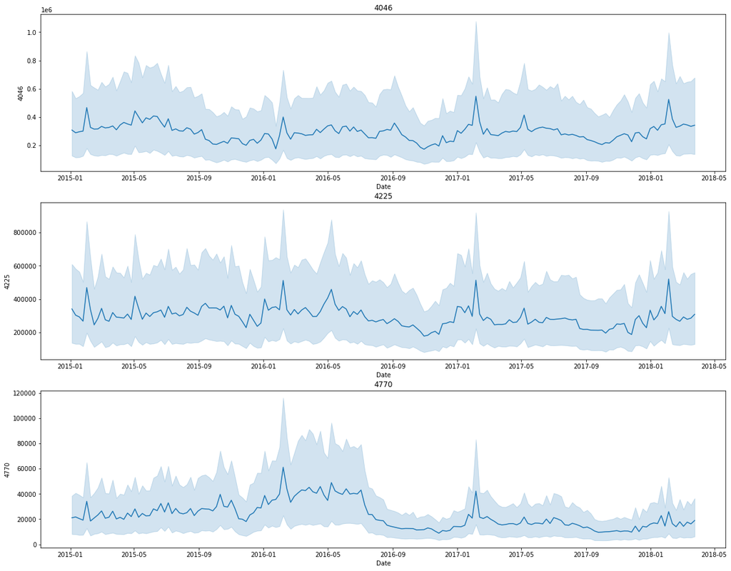

```python
f, axes = plt.subplots(3, 1, figsize=(20, 16))
sns.lineplot(data=df, x='Date', y='4046',palette='magma', ax=axes[0])
sns.lineplot(data=df, x='Date', y='4225',palette='magma', ax=axes[1])
sns.lineplot(data=df, x='Date', y='4770',palette='magma', ax=axes[2])
axes[0].set_title('4046')
axes[1].set_title('4225')
axes[2].set_title('4770')
```

### Посмотрим на распределение цен по годам.

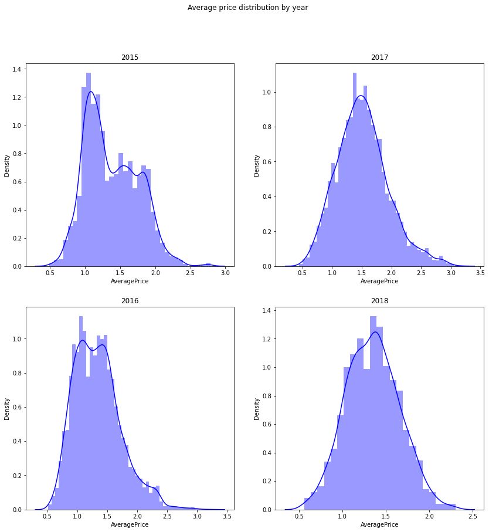

```python
f, axes = plt.subplots(2, 2, figsize=(14, 14))
f.suptitle('Average price distribution by year')
for i in range(4):
    first = int(i % 2)
    second = int(i / 2)
    sns.distplot(df[df['year'] == 2015 + i]['AveragePrice'], color = 'b', ax=axes[first, second])
    axes[first,second].set_title(str(2015+i))
```

### Видно, что цена с годами постепенно растёт (наверное, тут замешана инфляция). Также видно, что в 2015 году видно очень крупный блок продаж авокадо со среднем ценой ~1.1 USD, а затем блок продаж ценой 1.5-2 USD. В 2016 году картина становится более гладкой. 2017 и 2018 года очень сильно напоминают нам нормальное распределение, в 2017 года средняя цена была выше, чем в 2018 году, это может быть вызвано природными факторами.

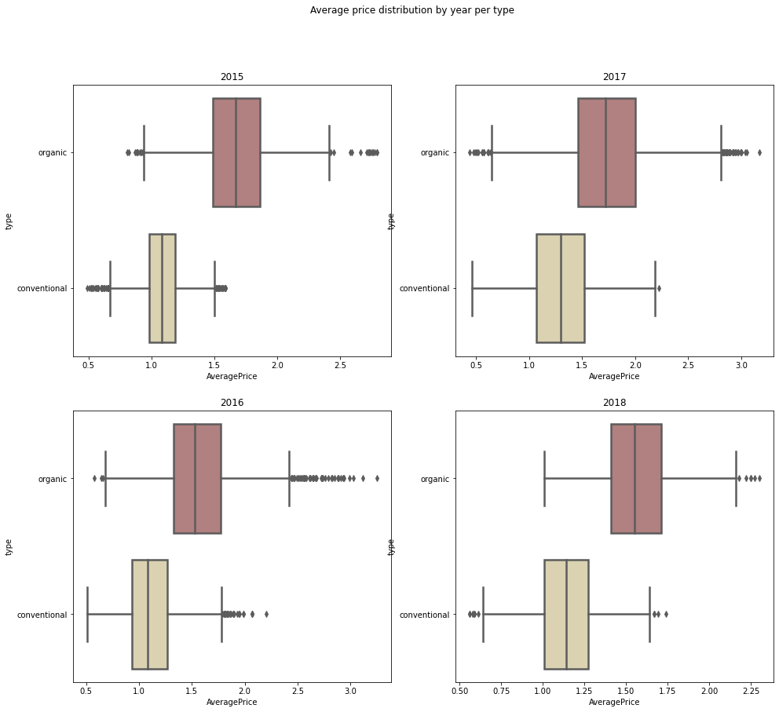

```python
f, axes = plt.subplots(2, 2, figsize=(16, 14))
f.suptitle('Average price distribution by year per type')
for i in range(4):
    first = int(i % 2)
    second = int(i / 2)
    sns.boxplot(y="type", x="AveragePrice", data=df[df['year'] == 2015+i], linewidth=2.5, palette = 'pink', ax=axes[first, second])
    axes[first,second].set_title(str(2015+i))
```

### Вполне очевидно, что органически выращенные авокадо стоят дороже. Однако, интересен тот факт, что если в 2015 году самые дорогие авокадо, выращенные не органич., стоили дешевле, чем авокадо с 0.25-квантиля до 0.5-квантиля. Дальше разрыв уменьшается, но все равно остается видимым.

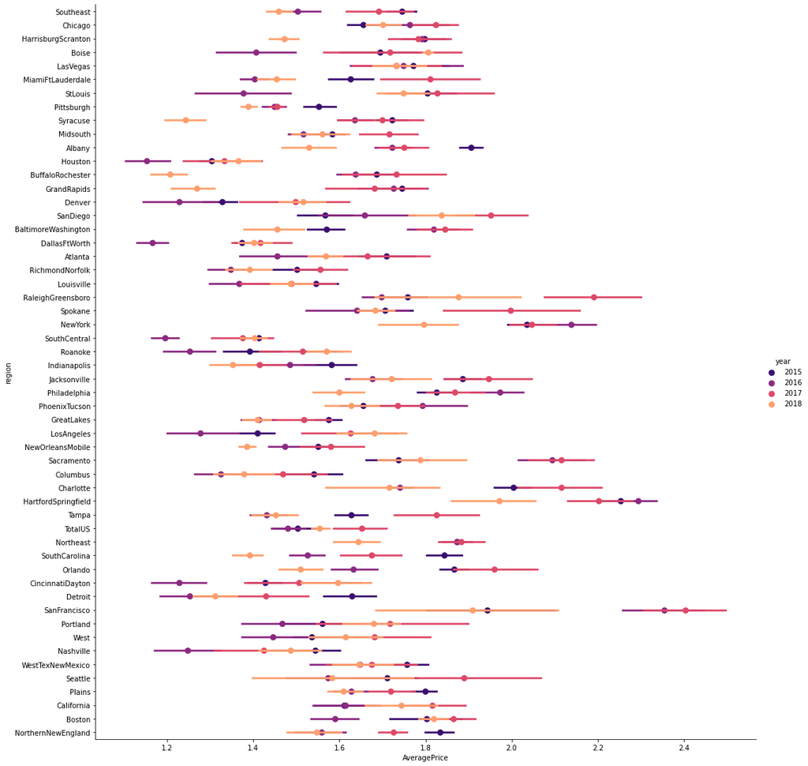

```python
sns.factorplot('AveragePrice','region',data=df[df['type'] == 'organic'],
                   hue='year',
                   size=15,
                   aspect=1.0,
                   palette='magma',
                   join=False)
```

### Хорошо видно лидеров по средним ценам по годам. Похоже, надо направляться в Сиракьюс или же в Баффало, чтобы урвать самые дешевые авокадо в 18 году.

# Проверка статистических гипотез

### Начнем проверять наши статистические гипотезы.

### H0: стоимость авокадо не зависят от типа (органик = традиционно выращ.)

### H1: стоимости различны

### Воспользуемся критерием Стьюдента для данного исследования.

```python
avocado_organic_sample = df[df['type'] == 'organic']
avocado_conventional_sample = df[df['type'] == 'conventional']
```

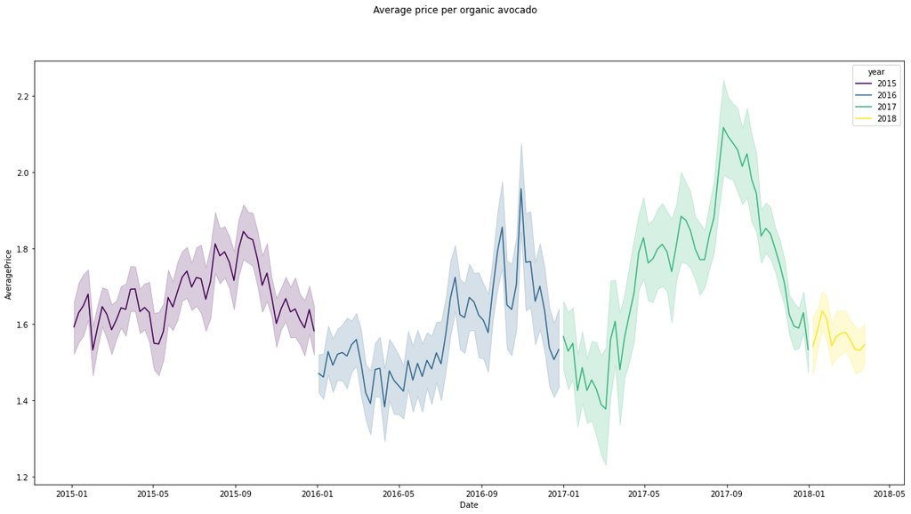

```python
fig, ax = plt.subplots()
fig.set_size_inches(20,10)
fig.suptitle('Average price per organic avocado')
sns.lineplot(data=avocado_organic_sample, x='Date',palette='viridis', y='AveragePrice', hue='year', ax=ax)
```

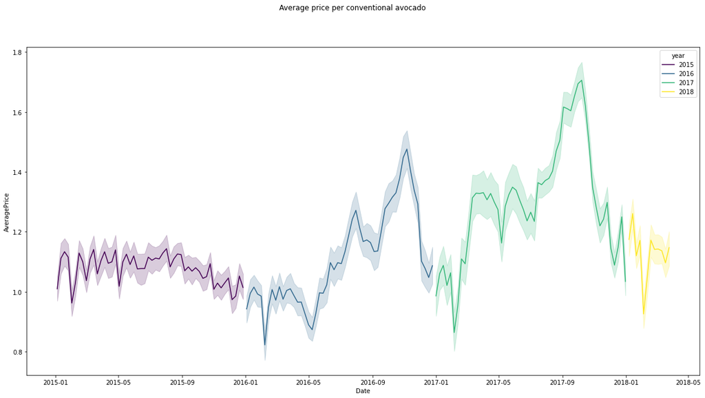

```python
fig, ax = plt.subplots()
fig.set_size_inches(20,10)
fig.suptitle('Average price per conventional avocado')
sns.lineplot(data=avocado_conventional_sample, x='Date',palette='viridis', y='AveragePrice', hue='year', ax=ax)
```

```python
print(avocado_organic_sample.shape)
print(avocado_conventional_sample.shape)
```

```
(9123, 13)
(9126, 13)
```

### С помощью критерия Шапиро-Уилка рассмотрим, имеет ли выборка нормальное распределение. (Дополнительно проверим по графикам)

```python
stats.shapiro(avocado_organic_sample['AveragePrice'])
```

```
ShapiroResult(statistic=0.987278401851654, pvalue=8.35322231792404e-28)
```

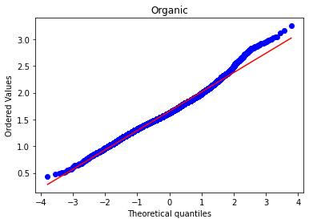

```python
stats.probplot(avocado_organic_sample['AveragePrice'], dist = "norm", plot = plt)
plt.title('Organic')
plt.show()
```

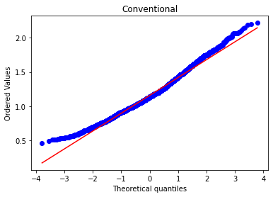

```python
stats.probplot(avocado_conventional_sample['AveragePrice'], dist = "norm", plot = plt)
plt.title('Conventional')
plt.show()
```

```python
stats.shapiro(avocado_conventional_sample['AveragePrice'])
```

```
ShapiroResult(statistic=0.9855247735977173, pvalue=1.782527006287485e-29)
```

```python
stats.ttest_rel(avocado_organic_sample.AveragePrice, avocado_conventional_sample.head(9123).AveragePrice)
```

```
Ttest_relResult(statistic=117.61419746862336, pvalue=0.0)
```

### Получается, отрицаем нашу H0-гипотезу. Цена зависит от типа.

# Предсказание временного ряда

```python
us_price = pd.read_csv('./avocado.csv', sep =',',
                                 parse_dates=['Date'], index_col='Date')
us_price.sort_index(inplace=True)
```

```python
us_price = us_price.groupby(us_price.region).get_group('TotalUS')
```

```python
us_price
```

| Date | Unnamed: 0 | AveragePrice | Total Volume | 4046 | 4225 | 4770 | Total Bags | Small Bags | Large Bags | XLarge Bags | type | year | region |
| --- | --- | --- | --- | --- | --- | --- | --- | --- | --- | --- | --- | --- | --- |
| 2015-01-04 | 51 | 0.95 | 31324277.73 | 12357161.34 | 13624083.05 | 844093.32 | 4498940.02 | 3585321.58 | 894945.63 | 18672.81 | conventional | 2015 | TotalUS |
| 2015-01-04 | 51 | 1.46 | 612910.15 | 233286.13 | 216611.20 | 4370.99 | 158641.83 | 115068.71 | 43573.12 | 0.00 | organic | 2015 | TotalUS |
| 2015-01-11 | 50 | 1.42 | 669528.88 | 270966.74 | 260971.60 | 3830.42 | 133760.12 | 106844.49 | 26915.63 | 0.00 | organic | 2015 | TotalUS |
| 2015-01-11 | 50 | 1.01 | 29063542.75 | 11544810.53 | 12134773.38 | 866574.66 | 4517384.18 | 3783261.16 | 718333.87 | 15789.15 | conventional | 2015 | TotalUS |
| 2015-01-18 | 49 | 1.42 | 713120.00 | 254319.58 | 311811.01 | 4020.85 | 142968.56 | 101850.23 | 41118.33 | 0.00 | organic | 2015 | TotalUS |
| ... | ... | ... | ... | ... | ... | ... | ... | ... | ... | ... | ... | ... | ... |
| 2018-03-11 | 2 | 1.09 | 40449603.12 | 14089091.05 | 10758039.45 | 707578.82 | 14894893.80 | 11392828.89 | 3229556.62 | 272508.29 | conventional | 2018 | TotalUS |
| 2018-03-18 | 1 | 1.54 | 1675804.22 | 170801.85 | 444949.69 | 1045.38 | 1058651.50 | 837351.85 | 221129.46 | 170.19 | organic | 2018 | TotalUS |
| 2018-03-18 | 1 | 1.05 | 41386314.12 | 13707389.51 | 11061051.69 | 645380.85 | 15972492.07 | 11712807.19 | 3988101.74 | 271583.14 | conventional | 2018 | TotalUS |
| 2018-03-25 | 0 | 1.55 | 1559967.20 | 121007.94 | 342853.10 | 1070.24 | 1093861.09 | 902774.79 | 190941.84 | 144.46 | organic | 2018 | TotalUS |
| 2018-03-25 | 0 | 1.03 | 43409835.75 | 14130799.10 | 12125711.42 | 758801.12 | 16394524.11 | 12540327.19 | 3544729.39 | 309467.53 | conventional | 2018 | TotalUS |

338 rows × 13 columns

### Произведём декомпозицию нашего временного ряда для conventional и organic по отдельности.

```python
us_price_conventional = us_price[us_price['type'] == 'conventional']
us_price_organic = us_price[us_price['type'] == 'organic']
```

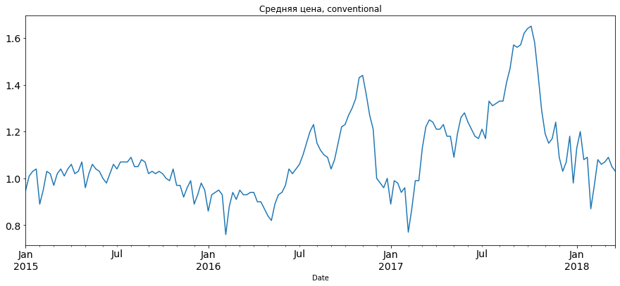

```python
us_price_conventional.AveragePrice.plot( figsize=(15,6),title= 'Средняя цена, conventional', fontsize=14)
```

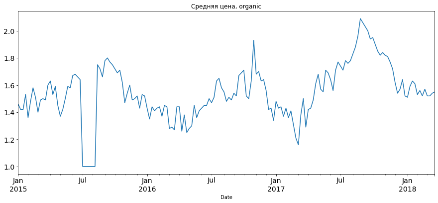

```python
us_price_organic.AveragePrice.plot( figsize=(15,6),title= 'Средняя цена, organic', fontsize=14)
```

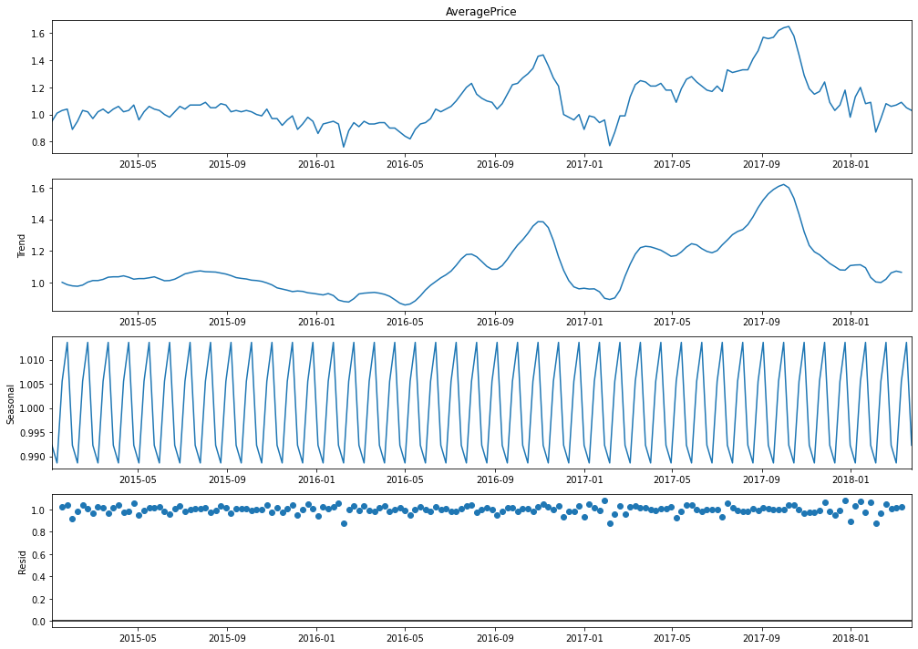

```python
rcParams['figure.figsize'] = 14, 10
result = sm.tsa.seasonal_decompose(us_price_conventional.AveragePrice, model='multiplicative',freq=4) # в среднем у нас по 4-5 записей на месяц, поэтому возьмем частоту 4
result.plot()
plt.show()
```

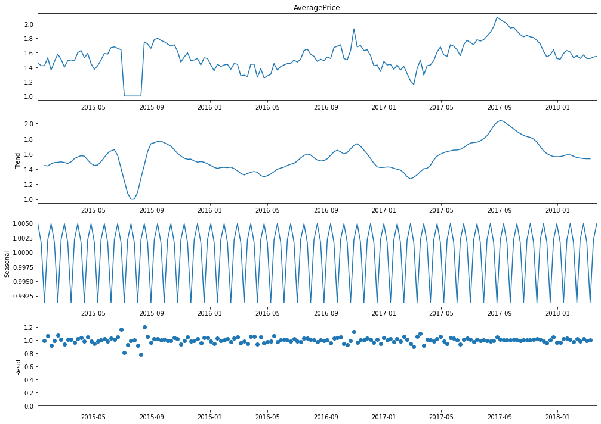

```python
rcParams['figure.figsize'] = 14, 10
result = sm.tsa.seasonal_decompose(us_price_organic.AveragePrice, model='multiplicative',freq=4) # в среднем у нас по 4-5 записей на месяц, поэтому возьмем частоту 4
result.plot()
plt.show()
```